# Reproducible Research: Peer Assessment 1

OS: Windows 8.1

R version: x64 3.1.2

R-studio version: 0.98

Required packages: core packages, lubridate

## Loading and preprocessing the data

The code below reads data into R. It assumes that the relevant data file is presented in your working directory and is called “activity.css”.

```r
require(lubridate)
data <- read.csv("activity.csv",colClasses=c("integer","character","integer"))
data <- transform(data, date = ymd(date))
```

## What is mean total number of steps taken per day?

The code below produces a histogram for the total number of steps taken per day and calculates a mean and a median for it. NAs are ignored at this step.

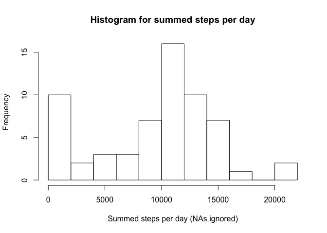

```r
steps_per_day <- split(data$steps, data$date)
sum_steps_per_day <- sapply(steps_per_day, function(x) {sum(x, na.rm = TRUE)})
hist(sum_steps_per_day, breaks = 9, main = "Histogram for summed steps per day", xlab = "Summed steps per day (NAs ignored)")
```

```r
daily_mean <- mean(sum_steps_per_day)
daily_median <- median(sum_steps_per_day)
```

The mean is **9354.2295082**.

The median is **10395**.

## What is the average daily activity pattern?

The code below produces a time-series plot of the average numbers of steps taken in a certain time interval across various days. NAs are again ignored.

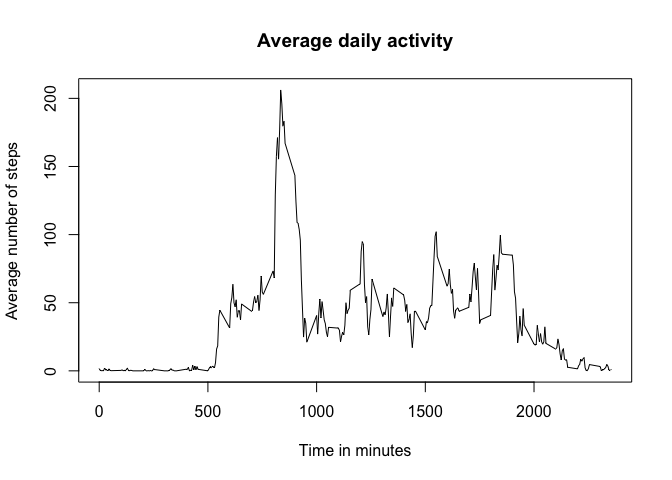

```r
steps_per_interval <- split(data$steps, data$interval)
mean_steps_per_interval <- sapply(steps_per_interval, function(x) {mean(x, na.rm = TRUE)})
intervals <- as.integer(names(mean_steps_per_interval))
plot(x = intervals, y = mean_steps_per_interval, type = "l", main = "Average daily activity", xlab = "Time in minutes", ylab = "Average number of steps")
```

```r
named_max_steps <- mean_steps_per_interval[mean_steps_per_interval == max(mean_steps_per_interval)]
max_steps_interval <- as.integer(names(named_max_steps))
```

## Imputing missing values

```r
NAs <- sum(is.na(data$steps))
```

The number of NAs is **2304**. We can fill them.

```r
fillNAs <- function(data, steps) {
      interval_names <- as.integer(names(steps))
      for (i in 1:nrow(data)) {
            if (is.na(data$steps[i])) {
                  data$steps[i] = as.integer(steps[interval_names == data$interval[i]])
            }
      }
      data
}
data_noNAs <- fillNAs(data, mean_steps_per_interval)
```

Now that the NAs are filled in, the comparissons can be made.

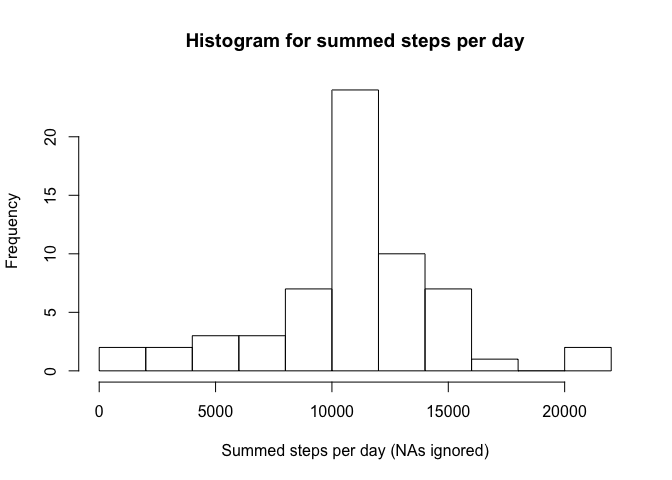

```r
steps_per_day_noNAs <- split(data_noNAs$steps, data_noNAs$date)
sum_steps_per_day_noNAs <- sapply(steps_per_day_noNAs, function(x) {sum(x, na.rm = TRUE)})
hist(sum_steps_per_day_noNAs, breaks = 9, main = "Histogram for summed steps per day", xlab = "Summed steps per day (NAs ignored)")
```

```r
daily_mean_noNAs <- mean(sum_steps_per_day_noNAs)
daily_median_noNAs <- median(sum_steps_per_day_noNAs)
mean_change <- daily_mean_noNAs - daily_mean
median_change <- daily_median_noNAs - daily_median
```

The new median is **10641**. The median has faced a change of **246**.

## Are there differences in activity patterns between weekdays and weekends?

The code below plots the patterns of activity on weekdays and weekends separately so a reader can compare them. For that the dataset is split by a new factor variable. The levels of this variable represent the types of a day: either a weekday or a weekend.

```r
week_day <- wday(data_noNAs$date)
num_observ <- nrow(data_noNAs)
datetype <- character(num_observ)
for (i in 1:num_observ) {
      if (week_day[i] == 1 | week_day[i] == 7) {
            datetype[i] <- "weekend"
      } else {
            datetype[i] <- "weekday"
      }
}
datetype <- as.factor(datetype)
data_wdatetype <- cbind(data_noNAs,datetype)
data_weekday <- subset(data_wdatetype, datetype == "weekday")
data_weekend <- subset(data_wdatetype, datetype == "weekend")
```

Now that the dataset is split by the new variable, the plots can be produced.

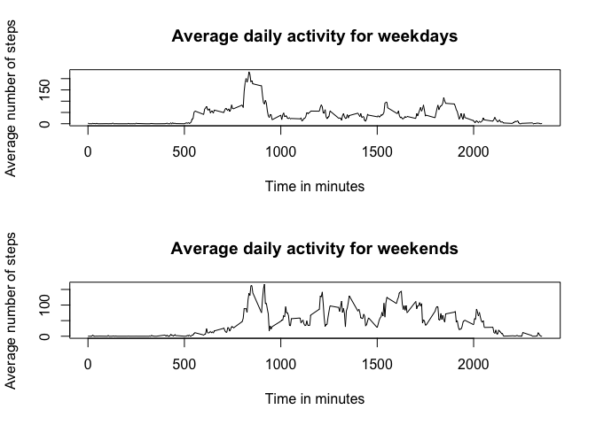

```r
par(mfrow=c(2,1))
steps_per_interval <- split(data_weekday$steps, data_weekday$interval)
mean_steps_per_interval <- sapply(steps_per_interval, function(x) {mean(x, na.rm = TRUE)})
intervals <- as.integer(names(mean_steps_per_interval))
plot(x = intervals, y = mean_steps_per_interval, type = "l", main = "Average daily activity for weekdays", xlab = "Time in minutes", ylab = "Average number of steps")
steps_per_interval <- split(data_weekend$steps, data_weekend$interval)
mean_steps_per_interval <- sapply(steps_per_interval, function(x) {mean(x, na.rm = TRUE)})
intervals <- as.integer(names(mean_steps_per_interval))
plot(x = intervals, y = mean_steps_per_interval, type = "l", main = "Average daily activity for weekends", xlab = "Time in minutes", ylab = "Average number of steps")
```